# The Sampling Distribution of the Mean

David Gresham

2026-06-10

## The Population

We start with a **non-normal** population to make the Central Limit Theorem more striking. Here we use a right-skewed distribution (exponential), so the population itself looks nothing like a normal distribution.

```r
N <- 100000  # large population
population <- rexp(N, rate = 0.5)  # exponential: mean = 2, SD = 2, strongly right-skewed

pop_mean <- mean(population)
pop_sd   <- sd(population)

cat(sprintf("Population mean:  %.3f\n", pop_mean))
```

```
Population mean:  1.996
```

```r
cat(sprintf("Population SD:    %.3f\n", pop_sd))
```

```
Population SD:    2.001
```

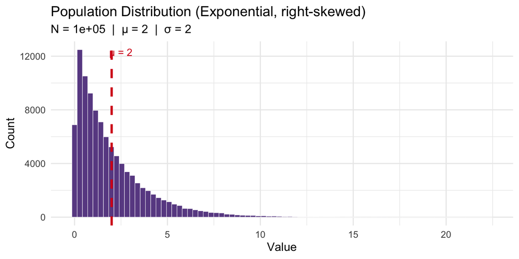

```r
ggplot(data.frame(x = population), aes(x = x)) +
  geom_histogram(bins = 80, fill = "#6a4c93", color = "white", linewidth = 0.2) +
  geom_vline(xintercept = pop_mean, color = "#d7191c", linewidth = 1.2, linetype = "dashed") +
  annotate("text", x = pop_mean + 0.5, y = Inf, label = paste("μ =", round(pop_mean, 2)),
           vjust = 2, color = "#d7191c", size = 4) +
  labs(
    title = "Population Distribution (Exponential, right-skewed)",
    subtitle = paste0("N = ", format(N, big.mark = ","), "  |  μ = ", round(pop_mean, 2),
                      "  |  σ = ", round(pop_sd, 2)),
    x = "Value", y = "Count"
  ) +
  theme_minimal(base_size = 13)
```

The population is clearly **not normal** — it has a long right tail. This is intentional: we want to watch the Central Limit Theorem (CLT) convert this ugly shape into something bell-shaped as sample size grows.

## Sampling: The Core Idea

For each of three sample sizes (small, medium, large), we:

1. Draw **1,000 independent random samples** of that size from the population.
2. Compute the **mean of each sample**.
3. Plot the distribution of those 1,000 sample means.

The resulting distribution is called the **sampling distribution of the mean**.

```r
#' Draw `n_sims` samples of size `n` from `pop`, return vector of sample means
sample_means <- function(pop, n, n_sims = 1000) {
  replicate(n_sims, mean(sample(pop, size = n, replace = FALSE)))
}

sample_sizes <- c(small = 5, medium = 30, large = 100)
n_sims       <- 1000

results <- map_dfr(
  sample_sizes,
  ~ data.frame(sample_mean = sample_means(population, .x, n_sims)),
  .id = "size"
) |>
  mutate(
    size = factor(size, levels = c("small", "medium", "large"),
                  labels = c("Small  (n = 5)", "Medium  (n = 30)", "Large  (n = 100)"))
  )
```

## Visualising the Three Sampling Distributions

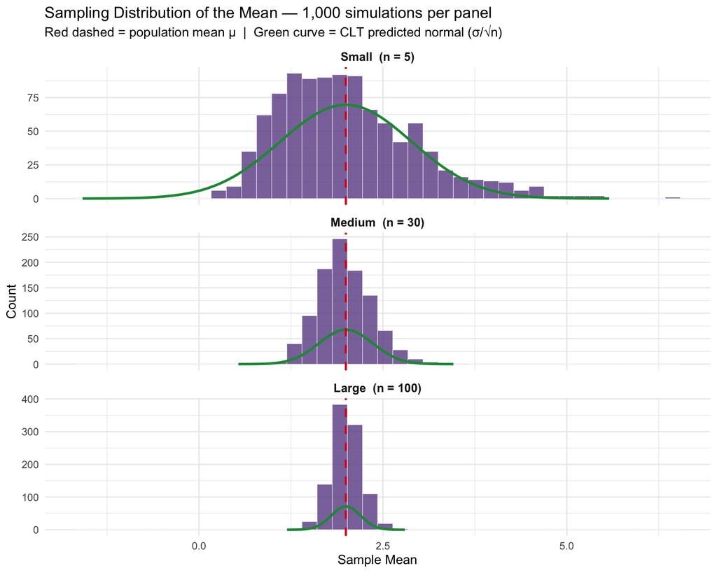

```r
# Compute the theoretical normal overlay for each panel
overlay_df <- data.frame(
  size = factor(
    c("Small  (n = 5)", "Medium  (n = 30)", "Large  (n = 100)"),
    levels = c("Small  (n = 5)", "Medium  (n = 30)", "Large  (n = 100)")
  ),
  n = c(5, 30, 100)
) |>
  mutate(
    se = pop_sd / sqrt(n),
    x_min = pop_mean - 4 * se,
    x_max = pop_mean + 4 * se
  )

# Build a fine grid of x values per panel for the normal curve
normal_curves <- overlay_df |>
  rowwise() |>
  reframe(
    size = size,
    x    = seq(x_min, x_max, length.out = 400),
    y    = dnorm(x, mean = pop_mean, sd = pop_sd / sqrt(n))
  )

# Scale the density curve to match the histogram's count axis
bin_width <- results |>
  group_by(size) |>
  summarise(bw = diff(range(sample_mean)) / 40, .groups = "drop")

normal_curves <- normal_curves |>
  left_join(bin_width, by = "size") |>
  mutate(y_scaled = y * n_sims * bw)

p_sampling <- ggplot(results, aes(x = sample_mean)) +
  geom_histogram(bins = 40, fill = "#6a4c93", color = "white", linewidth = 0.2, alpha = 0.8) +
  geom_line(data = normal_curves, aes(x = x, y = y_scaled),
            color = "#1a9641", linewidth = 1.2) +
  geom_vline(xintercept = pop_mean, color = "#d7191c",
             linewidth = 1, linetype = "dashed") +
  facet_wrap(~ size, ncol = 1, scales = "free_y") +
  labs(
    title    = "Sampling Distribution of the Mean — 1,000 simulations per panel",
    subtitle = "Red dashed = population mean μ  |  Green curve = CLT predicted normal (σ/√n)",
    x        = "Sample Mean",
    y        = "Count"
  ) +
  theme_minimal(base_size = 13) +
  theme(strip.text = element_text(face = "bold", size = 12))

p_sampling
```

```r
dir.create("plots", showWarnings = FALSE)
ggsave("plots/sampling_dist_preview.png", p_sampling,
       width = 7, height = 6, dpi = 150, bg = "white")
```

## What’s Happening at Each Sample Size?

### Small samples (n = 5)

With only 5 observations per sample, the distribution of means is still **noticeably skewed** — it hasn’t shed the asymmetry of the parent population. The standard error (σ/√5 ≈ 0.89) is large, so the means are spread widely. Individual extreme values still dominate.

### Medium samples (n = 30)

By n = 30 — the traditional rule-of-thumb threshold — the distribution looks **approximately normal**. The skewness is nearly gone. The SE has shrunk to σ/√30 ≈ 0.37. This is the CLT in action: you don’t need the population to be normal, you just need enough observations.

## Standard Error: The Width of the Sampling Distribution

The standard error (SE = σ/√n) tells you how spread out sample means will be. The table and plot below show it shrinks with the square root of n — doubling precision requires **quadrupling** sample size.

```r
ns <- c(5, 10, 20, 30, 50, 100, 200, 500)

se_df <- data.frame(
  n  = ns,
  SE = pop_sd / sqrt(ns)
)

knitr::kable(se_df, digits = 3,
             col.names = c("Sample size (n)", "Standard Error (σ/√n)"))
```

| Sample size (n) | Standard Error (σ/√n) |
| --- | --- |
| 5 | 0.895 |
| 10 | 0.633 |
| 20 | 0.447 |
| 30 | 0.365 |
| 50 | 0.283 |
| 100 | 0.200 |
| 200 | 0.142 |
| 500 | 0.089 |

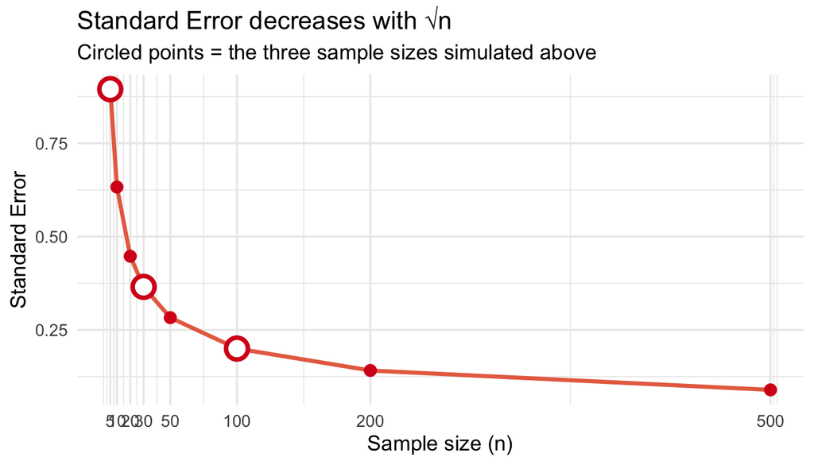

```r
ggplot(se_df, aes(x = n, y = SE)) +
  geom_line(color = "#e76f51", linewidth = 1.2) +
  geom_point(color = "#d7191c", size = 3) +
  geom_point(data = filter(se_df, n %in% c(5, 30, 100)),
             color = "#d7191c", size = 5, shape = 21, fill = "white", stroke = 2) +
  scale_x_continuous(breaks = ns) +
  labs(
    title    = "Standard Error decreases with √n",
    subtitle = "Circled points = the three sample sizes simulated above",
    x        = "Sample size (n)",
    y        = "Standard Error"
  ) +
  theme_minimal(base_size = 13)
```

## Key Takeaways

| Concept | What it means |
| --- | --- |
| **Sampling distribution** | The distribution of a statistic (here, the mean) across many repeated samples |
| **Central Limit Theorem** | The sampling distribution of the mean → Normal as n grows, *regardless* of population shape |
| **Standard Error** | SD of the sampling distribution = σ/√n; controls how precisely a sample mean estimates μ |
| **n = 30 rule of thumb** | Often sufficient for the CLT to kick in, *unless* the population is extremely skewed or has heavy tails |

The deeper point: **we never actually draw 1,000 samples in real research**. This simulation just makes visible what the CLT guarantees mathematically — that a single large sample’s mean is, with high probability, close to μ.